# EventsOrig behavioral

Anna Ivanova

6/25/2021

# EVENTSORIG

## Load behavioral data

## Response Rate

```
## # A tibble: 4 × 2
##   Condition ResponseRate
##   <fct>            <dbl>
## 1 Pic_Perc         0.841
## 2 Sent_Perc        0.768
## 3 Pic_Sem          0.896
## 4 Sent_Sem         0.682
```

Average response rate was 0.797.

## Reaction Times

```
## Sent Sem RT = 1.088 (SD =  0.24 )
```

```
## Sent Perc RT = 1.014 (SD =  0.225 )
```

```
## Pic Sem RT = 0.983 (SD =  0.183 )
```

```
## Pic Perc RT = 1.009 (SD =  0.21 )
```

```
## Overall= 1.02 (SD =  0.217 )
```

Overall reaction time was 1.02s, SD=0.22 (Sent Sem: 1.09s, SD=0.24; Sent Perc: 1.01s, SD=0.23, Pic Sem: 0.98s, SD=0.18, Pic Perc: 1.01s, SD=0.21)

```
## Linear mixed model fit by maximum likelihood . t-tests use
##   Satterthwaite's method [lmerModLmerTest]
## Formula: RT ~ StimType * Task + (1 | SubjID)
##    Data: dat_RT
## Control: lmerControl(optimizer = "bobyqa", optCtrl = list(maxfun = 2e+05))
##
##      AIC      BIC   logLik deviance df.resid
##  -1258.0  -1220.8    635.0  -1270.0     3666
##
## Scaled residuals:
##     Min      1Q  Median      3Q     Max
## -5.7516 -0.6559  0.0052  0.7121  2.5541
##
## Random effects:
##  Groups   Name        Variance Std.Dev.
##  SubjID   (Intercept) 0.004507 0.06713
##  Residual             0.040955 0.20237
## Number of obs: 3672, groups:  SubjID, 12
##
## Fixed effects:
##                                Estimate Std. Error        df t value
## (Intercept)                   1.031e+00  1.968e-02 1.201e+01  52.404
## StimTypeSent>Pic              5.882e-02  6.731e-03 3.661e+03   8.739
## TaskSem>Perc                  2.307e-02  6.730e-03 3.661e+03   3.428
## StimTypeSent>Pic:TaskSem>Perc 1.024e-01  1.344e-02 3.660e+03   7.619
##                               Pr(>|t|)
## (Intercept)                   1.48e-15 ***
## StimTypeSent>Pic               < 2e-16 ***
## TaskSem>Perc                  0.000614 ***
## StimTypeSent>Pic:TaskSem>Perc 3.23e-14 ***
## ---
## Signif. codes:  0 '***' 0.001 '**' 0.01 '*' 0.05 '.' 0.1 ' ' 1
##
## Correlation of Fixed Effects:
##             (Intr) StTS>P TskS>P
## StmTypSnt>P 0.017
## TaskSem>Prc 0.003  0.049
## StTS>P:TS>P 0.008  0.020  0.093
```

## Accuracies

```
## Sent Sem Accuracy = 0.858 (SD =  0.35 )
```

```
## Sent Perc Accuracy = 0.725 (SD =  0.447 )
```

```
## Pic Sem Accuracy = 0.89 (SD =  0.314 )
```

```
## Pic Perc Accuracy = 0.785 (SD =  0.411 )
```

```
## Overall Accuracy= 0.8156318
```

Overall mean accuracy was 0.82, SD=0.39 (Sent Sem: 0.86, SD=0.35; Sent Perc: 0.73, SD=0.45, Pic Sem: 0.89, SD=0.31, Pic Perc: 0.79, SD=0.41)

```
## Generalized linear mixed model fit by maximum likelihood (Laplace
##   Approximation) [glmerMod]
##  Family: binomial  ( logit )
## Formula: Accuracy ~ StimType * Task + (1 | SubjID)
##    Data: dat_acc
##
##      AIC      BIC   logLik deviance df.resid
##   3293.8   3324.9  -1641.9   3283.8     3667
##
## Scaled residuals:
##     Min      1Q  Median      3Q     Max
## -5.0493  0.2800  0.3760  0.4989  0.8844
##
## Random effects:
##  Groups Name        Variance Std.Dev.
##  SubjID (Intercept) 0.3132   0.5596
## Number of obs: 3672, groups:  SubjID, 12
##
## Fixed effects:
##                               Estimate Std. Error z value Pr(>|z|)
## (Intercept)                    1.66730    0.16908   9.861  < 2e-16 ***
## StimTypeSent>Pic              -0.27934    0.09132  -3.059  0.00222 **
## TaskSem>Perc                   0.88394    0.09177   9.632  < 2e-16 ***
## StimTypeSent>Pic:TaskSem>Perc  0.11756    0.18255   0.644  0.51958
## ---
## Signif. codes:  0 '***' 0.001 '**' 0.01 '*' 0.05 '.' 0.1 ' ' 1
##
## Correlation of Fixed Effects:
##             (Intr) StTS>P TskS>P
## StmTypSnt>P 0.005
## TaskSem>Prc 0.079  0.033
## StTS>P:TS>P 0.013  0.253  0.011
```

## Plots

# EVENTS2MOVE

## Load behavioral data

## Response Rate

```
## # A tibble: 4 × 2
##   Condition ResponseRate
##   <fct>            <dbl>
## 1 Pic_Perc         0.898
## 2 Sent_Perc        0.898
## 3 Pic_Sem          0.924
## 4 Sent_Sem         0.848
```

Average response rate was 0.89.

## Reaction Times

```
## Sent Sem RT = 1.41 (SD =  0.559 )
```

```
## Sent Perc RT = 1.624 (SD =  0.443 )
```

```
## Pic Sem RT = 1.434 (SD =  0.416 )
```

```
## Pic Perc RT = 1.57 (SD =  0.489 )
```

```
## Overall= 1.51 (SD =  0.486 )
```

Overall reaction time was 1.51s, SD=0.49 (Sent Sem: 1.41s, SD=0.56; Sent Perc: 1.62s, SD=0.44, Pic Sem: 1.43s, SD=0.42, Pic Perc: 1.57s, SD=0.49)

```
## Linear mixed model fit by maximum likelihood . t-tests use
##   Satterthwaite's method [lmerModLmerTest]
## Formula: RT ~ StimType * Task + (1 | SubjID) + (1 | ItemNum)
##    Data: dat_RT
##
##      AIC      BIC   logLik deviance df.resid
##   3881.8   3923.8  -1933.9   3867.8     2989
##
## Scaled residuals:
##     Min      1Q  Median      3Q     Max
## -3.7464 -0.1162  0.2207  0.5224  2.0259
##
## Random effects:
##  Groups   Name        Variance Std.Dev.
##  ItemNum  (Intercept) 0.001773 0.04211
##  SubjID   (Intercept) 0.020443 0.14298
##  Residual             0.208121 0.45620
## Number of obs: 2996, groups:  ItemNum, 112; SubjID, 15
##
## Fixed effects:
##                                 Estimate Std. Error         df t value
## (Intercept)                      1.50016    0.03806   15.16754  39.413
## StimTypeSent>Pic                 0.01356    0.01669 2888.03027   0.813
## TaskSem>Perc                    -0.16954    0.01687 2731.62902 -10.048
## StimTypeSent>Pic:TaskSem>Perc   -0.08015    0.03338 2890.09586  -2.401
##                               Pr(>|t|)
## (Intercept)                     <2e-16 ***
## StimTypeSent>Pic                0.4165
## TaskSem>Perc                    <2e-16 ***
## StimTypeSent>Pic:TaskSem>Perc   0.0164 *
## ---
## Signif. codes:  0 '***' 0.001 '**' 0.01 '*' 0.05 '.' 0.1 ' ' 1
##
## Correlation of Fixed Effects:
##             (Intr) StTS>P TskS>P
## StmTypSnt>P 0.005
## TaskSem>Prc 0.002  0.023
## StTS>P:TS>P 0.005  0.008  0.021
```

RTs for the semantic task were slightly lower than for the perceptual task ($\beta$=-0.17, SE=0.02, p<.001), with an interaction between stimulus type and task ($\beta$=-0.08, SE=0.03, p=0.016). There was no main effect of stimulus type.

## Accuracies

```
## SentSem Accuracy= 0.6390449
```

```
## SentPerc Accuracy= 0.8421751
```

```
## PicSem Accuracy= 0.7744845
```

```
## PicPerc Accuracy= 0.8355438
```

```
## Overall Accuracy= 0.7746996
```

Overall mean accuracy was 0.77, SD=0.42 (Sent Sem: 0.64, SD=0.48; Sent Perc: 0.84, SD=0.36, Pic Sem: 0.77, SD=0.42, Pic Perc: 0.84, SD=0.37)

```
## Generalized linear mixed model fit by maximum likelihood (Laplace
##   Approximation) [glmerMod]
##  Family: binomial  ( logit )
## Formula: Accuracy ~ StimType * Task + (1 | SubjID) + (1 | ItemNum)
##    Data: dat_RT
##
##      AIC      BIC   logLik deviance df.resid
##   3038.6   3074.6  -1513.3   3026.6     2990
##
## Scaled residuals:
##     Min      1Q  Median      3Q     Max
## -3.4343  0.3019  0.4221  0.5368  1.3226
##
## Random effects:
##  Groups  Name        Variance Std.Dev.
##  ItemNum (Intercept) 0.1037   0.3220
##  SubjID  (Intercept) 0.1864   0.4317
## Number of obs: 2996, groups:  ItemNum, 112; SubjID, 15
##
## Fixed effects:
##                               Estimate Std. Error z value Pr(>|z|)
## (Intercept)                    1.32956    0.12525  10.616  < 2e-16 ***
## StimTypeSent>Pic              -0.32529    0.09269  -3.509 0.000449 ***
## TaskSem>Perc                  -0.79051    0.09476  -8.342  < 2e-16 ***
## StimTypeSent>Pic:TaskSem>Perc -0.75122    0.18534  -4.053 5.05e-05 ***
## ---
## Signif. codes:  0 '***' 0.001 '**' 0.01 '*' 0.05 '.' 0.1 ' ' 1
##
## Correlation of Fixed Effects:
##             (Intr) StTS>P TskS>P
## StmTypSnt>P -0.014
## TaskSem>Prc -0.076 -0.036
## StTS>P:TS>P -0.021 -0.173 -0.022
```

Accuracy was lower for the semantic task than for the perceptual task ($\beta$=-0.79, SE=0.09, p=0) and for sentence stimuli compared to picture stimuli ($\beta$=-0.33, SE=0.09, p=0), with an interaction between stimulus type and task ($\beta$=-0.75, SE=0.19, p=0).

## Plots

# EVENTSREV

## Load behavioral data

## Response Rate

```
## # A tibble: 4 × 2
##   Condition ResponseRate
##   <fct>            <dbl>
## 1 Pic_Perc         0.892
## 2 Pic_Sem          0.927
## 3 Sent_Perc        0.890
## 4 Sent_Sem         0.889
```

Average response rate was 0.9.

## Reaction Times

## Reaction Times

```
## Sent Sem RT = 1.119 (SD =  0.598 )
```

```
## Sent Perc RT = 1.025 (SD =  0.512 )
```

```
## Pic Sem RT = 1.143 (SD =  0.468 )
```

```
## Pic Perc RT = 1.059 (SD =  0.499 )
```

```
## Overall= 1.086 (SD =  0.523 )
```

Overall reaction time was 1.09s, SD=0.52 (Sent Sem: 1.12s, SD=0.6; Sent Perc: 1.03s, SD=0.51, Pic Sem: 1.14s, SD=0.47, Pic Perc: 1.06s, SD=0.5)

```
## Linear mixed model fit by maximum likelihood . t-tests use
##   Satterthwaite's method [lmerModLmerTest]
## Formula: RT ~ StimType * Task + (1 | SubjID) + (1 | ItemNum)
##    Data: dat_RT
##
##      AIC      BIC   logLik deviance df.resid
##   5123.1   5165.9  -2554.5   5109.1     3353
##
## Scaled residuals:
##     Min      1Q  Median      3Q     Max
## -2.5505 -0.3357  0.1909  0.6659  2.0354
##
## Random effects:
##  Groups   Name        Variance Std.Dev.
##  ItemNum  (Intercept) 0.001738 0.04169
##  SubjID   (Intercept) 0.006072 0.07792
##  Residual             0.263930 0.51374
## Number of obs: 3360, groups:  ItemNum, 40; SubjID, 21
##
## Fixed effects:
##                                 Estimate Std. Error         df t value
## (Intercept)                    1.086e+00  2.029e-02  2.460e+01  53.530
## StimTypeSent>Pic              -2.809e-02  1.777e-02  3.338e+03  -1.580
## TaskSem>Perc                   8.734e-02  1.785e-02  3.286e+03   4.893
## StimTypeSent>Pic:TaskSem>Perc  9.994e-03  3.560e-02  3.336e+03   0.281
##                               Pr(>|t|)
## (Intercept)                    < 2e-16 ***
## StimTypeSent>Pic                 0.114
## TaskSem>Perc                  1.04e-06 ***
## StimTypeSent>Pic:TaskSem>Perc    0.779
## ---
## Signif. codes:  0 '***' 0.001 '**' 0.01 '*' 0.05 '.' 0.1 ' ' 1
##
## Correlation of Fixed Effects:
##             (Intr) StTS>P TskS>P
## StmTypSnt>P  0.000
## TaskSem>Prc  0.001  0.003
## StTS>P:TS>P -0.001  0.002  0.001
```

RTs for the semantic task were slightly higher than for the perceptual task ($\beta$=0.09, SE=0.02, p<.001). There was no significant effect of stimulus type (sentences vs. pictures) and no interaction between stimulus type and task.

## Accuracies

```
## SentSem Accuracy= 0.8100775
```

```
## SentPerc Accuracy= 0.7788845
```

```
## PicSem Accuracy= 0.7481061
```

```
## PicPerc Accuracy= 0.7349398
```

```
## Overall Accuracy= 0.7681018
```

```
## Generalized linear mixed model fit by maximum likelihood (Laplace
##   Approximation) [glmerMod]
##  Family: binomial  ( logit )
## Formula: Accuracy ~ StimType * Task + (1 | SubjID) + (1 | ItemNum)
##    Data: dat_RT
##
##      AIC      BIC   logLik deviance df.resid
##   4391.2   4428.0  -2189.6   4379.2     3354
##
## Scaled residuals:
##     Min      1Q  Median      3Q     Max
## -2.2199 -1.1149  0.6064  0.8207  1.2931
##
## Random effects:
##  Groups  Name        Variance Std.Dev.
##  ItemNum (Intercept) 0.01261  0.1123
##  SubjID  (Intercept) 0.18095  0.4254
## Number of obs: 3360, groups:  ItemNum, 40; SubjID, 21
##
## Fixed effects:
##                               Estimate Std. Error z value Pr(>|z|)
## (Intercept)                    0.49951    0.10139   4.926 8.37e-07 ***
## StimTypeSent>Pic               0.12065    0.07259   1.662   0.0965 .
## TaskSem>Perc                   0.15743    0.07286   2.161   0.0307 *
## StimTypeSent>Pic:TaskSem>Perc -0.05517    0.14538  -0.380   0.7043
## ---
## Signif. codes:  0 '***' 0.001 '**' 0.01 '*' 0.05 '.' 0.1 ' ' 1
##
## Correlation of Fixed Effects:
##             (Intr) StTS>P TskS>P
## StmTypSnt>P  0.005
## TaskSem>Prc  0.006  0.001
## StTS>P:TS>P -0.001  0.017  0.015
```

Accuracy was higher for the semantic task than for the perceptual task ($\beta$=0.16, SE=0.07, p=0.031) There was no significant effect of stimulus type and no interaction between stimulus type and task.

## Plots

# COMBINE PLOTS

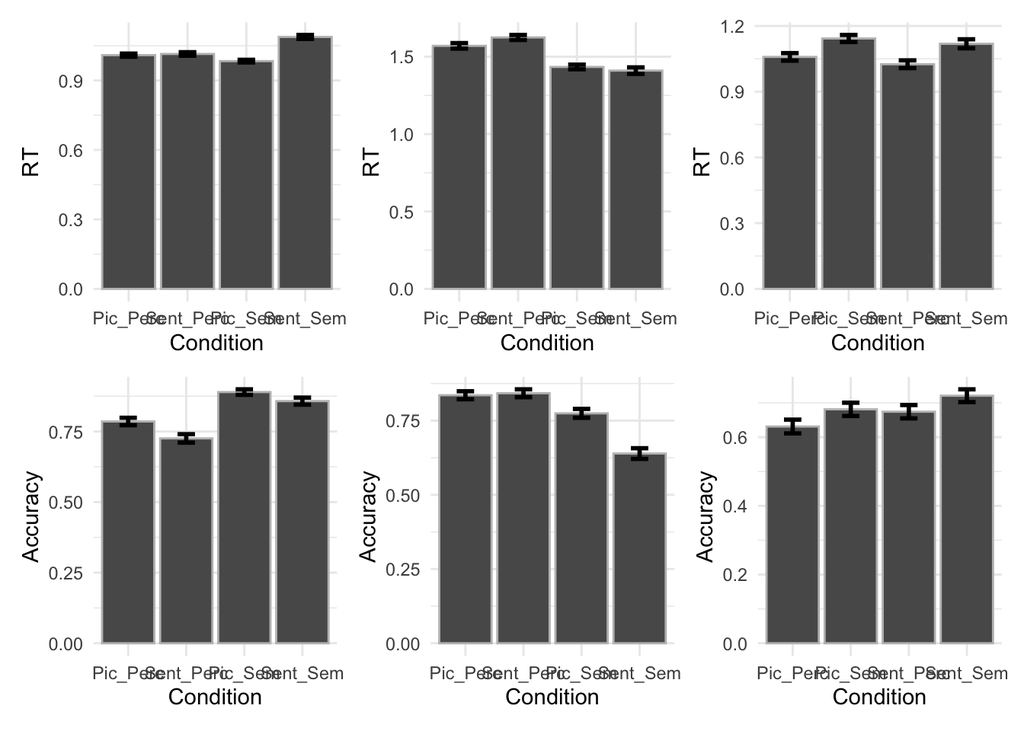